# **ExtraaLearn Project**

### **Tuning the Random Forest Model (GridsearchCV)**

To potentially improve the performance of the Random Forest Classifier and address any remaining overfitting, we will perform hyperparameter tuning using GridSearchCV. This involves searching over a predefined grid of hyperparameter values and evaluating the model's performance (using cross-validation on the training data) for each combination to find the optimal set of parameters. The `criterion` parameter determines the function used to measure the quality of a split in a decision tree. Common options are 'gini' for the Gini impurity and 'entropy' for the information gain. The `max_features` parameter controls the number of features to consider when looking for the best split at each node. 'sqrt' considers the square root of the total number of features, 'log2' considers the base-2 logarithm of the total number of features, and `None` considers all features. These options are common strategies to introduce randomness and reduce correlation among the trees in the forest.

```python
# Define the hyperparameter grid for Random Forest tuning
param_grid_rf = {
    'n_estimators': [100, 200, 300], # Number of trees in the forest
    'max_depth': [None, 10, 20, 30], # Maximum depth of the trees
    'min_samples_split': [2, 5, 10], # Minimum number of samples required to split an internal node
    'min_samples_leaf': [1, 2, 4], # Minimum number of samples required to be at a leaf node
    'max_features': ['sqrt', 'log2', None], # Number of features to consider when looking for the best split
    'criterion': ['gini', 'entropy'] # The function to measure the quality of a split
}

# Print the defined hyperparameter grid
print(param_grid_rf)
```

```
{'n_estimators': [100, 200, 300], 'max_depth': [None, 10, 20, 30], 'min_samples_split': [2, 5, 10], 'min_samples_leaf': [1, 2, 4], 'max_features': ['sqrt', 'log2', None], 'criterion': ['gini', 'entropy']}
```

```python
# Initialize Random Forest Classifier model
rf_model = RandomForestClassifier(random_state=42)

# Initialize GridSearchCV
grid_search_rf = GridSearchCV(estimator=rf_model, param_grid=param_grid_rf,
                             cv=5, scoring='roc_auc', n_jobs=-1, verbose=2) # Using roc_auc as the scoring metric, with 5-fold cross-validation

# Fit GridSearchCV to the training data
grid_search_rf.fit(X_train, y_train)

# Print the best hyperparameters found by GridSearchCV
print("Best hyperparameters found by GridSearchCV:", grid_search_rf.best_params_)
```

```
Fitting 5 folds for each of 648 candidates, totalling 3240 fits
Best hyperparameters found by GridSearchCV: {'criterion': 'entropy', 'max_depth': 10, 'max_features': 'sqrt', 'min_samples_leaf': 1, 'min_samples_split': 10, 'n_estimators': 200}
```

```python
# Initialize a new Random Forest model with the best hyperparameters found by GridSearchCV
tuned_rf_model = RandomForestClassifier(**grid_search_rf.best_params_, random_state=42)

# Train the tuned model and measure training time
start_time = time.time()
tuned_rf_model.fit(X_train, y_train)
training_time_tuned_rf = time.time() - start_time

# Make predictions on the training and testing sets and measure prediction time
start_time = time.time()
y_train_pred_tuned_rf = tuned_rf_model.predict(X_train)
train_prediction_time_tuned_rf = time.time() - start_time

start_time = time.time()
y_test_pred_tuned_rf = tuned_rf_model.predict(X_test)
test_prediction_time_tuned_rf = time.time() - start_time

# Get predicted probabilities for the testing set
y_test_proba_tuned_rf = tuned_rf_model.predict_proba(X_test)[:, 1]

# Evaluate the tuned model
test_report_tuned_rf = classification_report(y_test, y_test_pred_tuned_rf, output_dict=True)
test_roc_auc_tuned_rf = roc_auc_score(y_test, y_test_proba_tuned_rf)


# Store results in the dictionary
model_results['Tuned Random Forest'] = {
    'Training Report': classification_report(y_train, y_train_pred_tuned_rf, output_dict=True),
    'Training ROC AUC': roc_auc_score(y_train, tuned_rf_model.predict_proba(X_train)[:, 1]),
    'Training Confusion Matrix': confusion_matrix(y_train, y_train_pred_tuned_rf).tolist(),
    'Training Time (s)': training_time_tuned_rf,
    'Training Prediction Time (s)': train_prediction_time_tuned_rf,
    'Testing Report': test_report_tuned_rf,
    'Testing ROC AUC': test_roc_auc_tuned_rf,
    'Testing Confusion Matrix': confusion_matrix(y_test, y_test_pred_tuned_rf).tolist(),
    'Testing Prediction Time (s)': test_prediction_time_tuned_rf,
    'Testing Probabilities': y_test_proba_tuned_rf.tolist() # Store testing probabilities
}
```

```
Model Comparison Table (Sorted by Test ROC AUC):
```

|  | Accuracy (Train) | Precision (Train - Converted) | Recall (Train - Converted) | F1-score (Train - Converted) | ROC AUC (Train) | Accuracy (Test) | Precision (Test - Converted) | Recall (Test - Converted) | F1-score (Test - Converted) | ROC AUC (Test) | Training Time (s) | Prediction Time (s) |
| --- | --- | --- | --- | --- | --- | --- | --- | --- | --- | --- | --- | --- |
| Tuned Random Forest | 0.911365 | 0.877976 | 0.813419 | 0.844466 | 0.973713 | 0.857609 | 0.800000 | 0.724739 | 0.760512 | 0.928205 | 1.754174 | 0.051781 |
| Pruned Decision Tree | 0.873029 | 0.802927 | 0.756434 | 0.778987 | 0.925634 | 0.860870 | 0.806950 | 0.728223 | 0.765568 | 0.919101 | 0.028307 | 0.003221 |
| Random Forest | 0.999728 | 0.999082 | 1.000000 | 0.999541 | 1.000000 | 0.858696 | 0.807843 | 0.717770 | 0.760148 | 0.915903 | 0.740377 | 0.023888 |
| Logistic Regression | 0.834693 | 0.769663 | 0.629596 | 0.692619 | 0.867507 | 0.844565 | 0.788000 | 0.686411 | 0.733706 | 0.883454 | 0.063303 | 0.013574 |
| Decision Tree | 0.999728 | 1.000000 | 0.999081 | 0.999540 | 1.000000 | 0.810870 | 0.687708 | 0.721254 | 0.704082 | 0.786378 | 0.035452 | 0.002146 |

```
--- Confusion Matrices for Top 3 Models (Based on Test ROC AUC) ---
```

```
Feature Importances (Tuned Random Forest):
```

|  | 0 |
| --- | --- |
| first_interaction_Website | 0.227879 |
| time_spent_on_website | 0.210374 |
| profile_completed_Medium | 0.123171 |
| interaction_score | 0.092975 |
| age | 0.061395 |
| website_engagement | 0.060377 |
| page_views_per_visit | 0.048906 |
| last_activity_Phone Activity | 0.033334 |
| website_visits | 0.025937 |
| current_occupation_Unemployed | 0.024857 |
| current_occupation_Student | 0.023112 |
| last_activity_Website Activity | 0.021984 |
| profile_completed_Low | 0.013130 |
| referral_Yes | 0.011048 |
| educational_channels_Yes | 0.005198 |
| media_interaction | 0.004959 |
| print_media_type1_Yes | 0.004161 |
| digital_media_Yes | 0.003927 |
| print_media_type2_Yes | 0.003275 |

**dtype:** float64

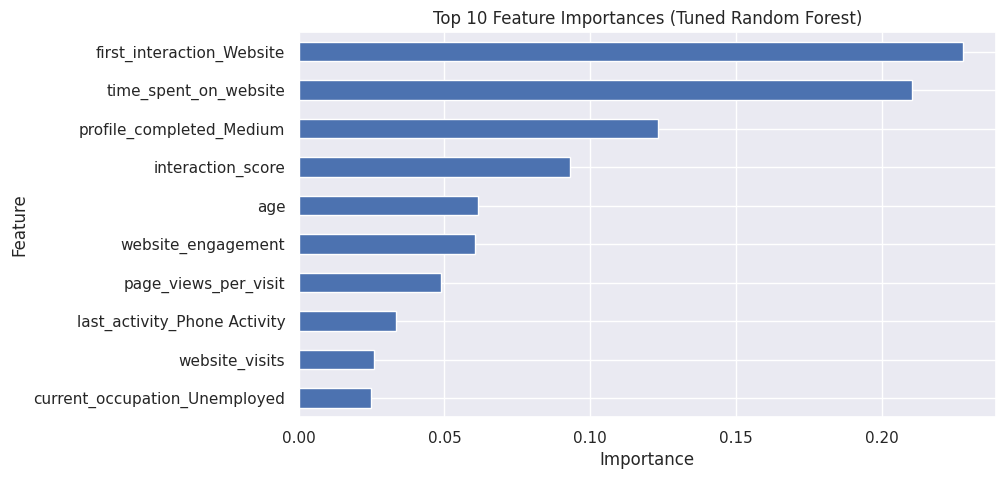

```python
# Display the model comparison table after Tuned Random Forest and capture the sorted DataFrame
results_df_sorted = display_model_comparison_table(model_results)

# Plot confusion matrices for the top models (adjust n as needed to include the new model)
plot_top_n_confusion_matrices(model_results, results_df_sorted, 3)

# Display feature importance for the Tuned Random Forest model
display_feature_importance(tuned_rf_model, X_train.columns, 'Tuned Random Forest')
```

[output not shown]